# MLG382 ASSIGNENT 3 [95 Marks]

**Lecturer: *K. Igwe***

# Evaluate the Performance of Logistic Regression, Random Forest , and any other Model of your Choice for Classifying Beverage as Local or Imported

A beverage company produces some of their beverage locally while some are imported. The experts assign each beverage a score which is an indication of the beverage quality. A socre ranges from 1 to 10 where 1 is the lowest quality and 10 is the highest quality. According to the experts, a beverage with a score in the rage 1 to 6 (inclusive) is regarded as a low quality beverage while those with a score in the rage 7 to 10 (inclusive) is regarded as a high quality beverage.

### Aim

- Given two datasets - local-beverage.csv and imported-beverges.csv, your first aim is to train models with these datasets such that the models can be used to classify beverage as imported or local.
- Your second aim is to evaluate and report the performance of the implemented models.

### Skills Tested

- Basic Python Programming
- EDA
- Use of sklearn Library
- Building a classification Model and applying cross-validation
- Understanding and using different evaluation techniques
- Reporting

### Instructions and Directions

1. **your code here** or **your answer here** need to be deleted and replaced with your code or answer
2. You may use more than one cell to answer a question
3. Ensure that you include appropriate comment
4. If your code requires special instruction or dependencies to run, please provide these in your submission

#### Import the required libraries [1]

```python
#imports

import pandas as pd
import numpy as np
import seaborn as sns
import matplotlib.pyplot as plt
%matplotlib inline
from sklearn.ensemble import ExtraTreesClassifier
from sklearn.model_selection import train_test_split,KFold,cross_val_score
from sklearn.linear_model import LogisticRegression
from sklearn.metrics import accuracy_score, recall_score, precision_score, f1_score,confusion_matrix,classification_report
from sklearn.preprocessing import StandardScaler
from sklearn.utils import class_weight
from sklearn.metrics import roc_curve, roc_auc_score
from sklearn.pipeline import Pipeline
from sklearn.ensemble import RandomForestClassifier
from sklearn.naive_bayes import GaussianNB
from sklearn.model_selection import StratifiedKFold
from sklearn.metrics import roc_curve, roc_auc_score
```

#### Load the local-beverage.csv (the dataset provided) and the importe-beverage.csv [2]

```python
# load data into panda array
local_beverages = pd.read_csv("local-beverage.csv")
imported_beverages = pd.read_csv("imported-beverage.csv")
```

#### Display information as well as a descriptive statistics of the features in each dataset [2]

```python
#display top 5 and last 5 entries of the dataset
#local

print('Local : ')
print(local_beverages,'\n')
print('Dataset info : ')
print('\nIs Null  : ')
#display the amount of records that are null
print(local_beverages.isnull().sum())
print('\nData type  : ')
#display data types
print(local_beverages.dtypes)
print('\nStatistical values  : ')
#give statistical information about dataset
print(local_beverages.describe())

#imported
print('\nImported : ')
print(imported_beverages,'\n')
print('\nDataset info : ')
print('\nIs Null  : ')
#display the amount of records that are null
print(imported_beverages.isnull().sum())
print('\nData type  : ')
#display data types
print(imported_beverages.dtypes)
print('\nStatistical values  : ')
#give statistical information about dataset
print(imported_beverages.describe())
```

```
Local :
      feature_1  feature_2  feature_3  feature_4  feature_5  feature_6  \
0           NaN      0.700       0.00        1.9       0.68      0.076
1           7.8      0.880       0.00        2.6       0.83      0.098
2           7.8      0.760       0.04        2.3       0.98      0.092
3          11.2      0.280       0.56        1.9       0.78      0.075
4           7.4      0.700       0.00        1.9       0.54      0.076
...         ...        ...        ...        ...        ...        ...
1594        6.2      0.600       0.08        2.0       0.54      0.090
1595        5.9      0.550       0.10        2.2       0.59      0.062
1596        6.3      0.510       0.13        2.3       0.83      0.076
1597        5.9      0.645       0.12        2.0       0.59      0.075
1598        6.0      0.310       0.47        3.6       0.88      0.067

      feature_7  feature_8  feature_9  feature_10  feature_11  feature_12  \
0          11.0       34.0         23     0.99780        3.51          94
1          25.0       67.0         34     0.99680        3.20          68
2          15.0       54.0         41     0.99700        3.26          92
3          17.0       60.0         49     0.99800        3.16          42
4          11.0       34.0         17     0.99780        3.51          47
...         ...        ...        ...         ...         ...         ...
1594       32.0       44.0         29     0.99490        3.45          75
1595       39.0       51.0         42     0.99512        3.52          80
1596       29.0       40.0         39     0.99574        3.42          85
1597       32.0       44.0         43     0.99547        3.57          81
1598       18.0       42.0         11     0.99549        3.39          18

      feature_13  feature_14  score
0           0.56         9.4      5
1           0.68         9.8      5
2           0.65         9.8      5
3           0.58         9.8      6
4           0.56         9.4      5
...          ...         ...    ...
1594        0.58        10.5      5
1595        0.76        11.2      6
1596        0.75        11.0      6
1597        0.71        10.2      5
1598        0.66        11.0      6

```

[output cut: 167 more lines]

```
min       0.009000     2.000000     9.000000    10.000000     0.987110
25%       0.036000    23.000000   108.000000    20.000000     0.991723
50%       0.043000    34.000000   134.000000    30.000000     0.993740
75%       0.050000    46.000000   167.000000    40.000000     0.996100
max       0.346000   289.000000   440.000000    50.000000     1.038980

        feature_11   feature_12   feature_13   feature_14        score
count  4898.000000  4898.000000  4879.000000  4898.000000  4898.000000
mean      3.188267    50.307677     0.489934    10.514267     5.877909
std       0.151001    29.340012     0.114203     1.230621     0.885639
min       2.720000     0.000000     0.220000     8.000000     3.000000
25%       3.090000    25.000000     0.410000     9.500000     5.000000
50%       3.180000    51.000000     0.470000    10.400000     6.000000
75%       3.280000    76.000000     0.550000    11.400000     6.000000
max       3.820000   100.000000     1.080000    14.200000     9.000000
```

#### Based on the information above, combine the local and imported beverage as you deem appropriate [4]

```python
#create a list that contains 0 for local beverages and 1 for imported beverages and then insert into respective dataset and then
# combine the two datasets into one dataset
imported=[]
i=0;
while i<len(local_beverages):
    imported.append(0)
    i+=1
local_beverages['imported']=imported

imported2=[]
j=0;
while j<len(imported_beverages):
    imported2.append(1)
    j+=1
imported_beverages['imported']=imported2

#here is the dataframe of the two previouse dataframes combined with a reset in index
df_beverages=local_beverages.append(imported_beverages)
df_beverages.reset_index(inplace=True)
df_beverages=df_beverages.drop(columns=['index'])
print(df_beverages)
```

```
      feature_1  feature_2  feature_3  feature_4  feature_5  feature_6  \
0           NaN       0.70       0.00        1.9       0.68      0.076
1           7.8       0.88       0.00        2.6       0.83      0.098
2           7.8       0.76       0.04        2.3       0.98      0.092
3          11.2       0.28       0.56        1.9       0.78      0.075
4           7.4       0.70       0.00        1.9       0.54      0.076
...         ...        ...        ...        ...        ...        ...
6492        6.2       0.21       0.29        1.6       0.70      0.039
6493        6.6       0.32       0.36        8.0       0.65      0.047
6494        6.5       0.24       0.19        1.2       0.50      0.041
6495        5.5       0.29       0.30        1.1       0.75      0.022
6496        6.0       0.21       0.38        0.8       0.80      0.020

      feature_7  feature_8  feature_9  feature_10  feature_11  feature_12  \
0          11.0       34.0         23     0.99780        3.51          94
```

[output cut: 25 more lines]

#### Handle missing data as you deem neccessary [2]

```python
#because there is not alot of records that contain NaN values relative to the size of the dataset that is 6497 i have decided that i will
#inmute these records by means of removal that will bring the amount of records down to 6346 which is only 151 records that was
# removed

print('Amount of records before removing NaN containing records : ')
print(len(df_beverages),"Records\n")
before=len(df_beverages)
df_beverages.dropna(inplace = True)# remove all rows that contain NaN values
print('Amount of records after removing NaN containing records : ')
print(len(df_beverages),"Records\n")
after=len(df_beverages)
total=before-after
print('records removed:',total)
```

```
Amount of records before removing NaN containing records :
6497 Records

Amount of records after removing NaN containing records :
6346 Records

records removed: 151
```

### Explore the features to understand the properties that can be used to determine whether or not the beverage is made locally or imported.

#### Using a heatmap, how do properties of the beverage correlate to each other and the beverage production type (local vs imported)? [5]

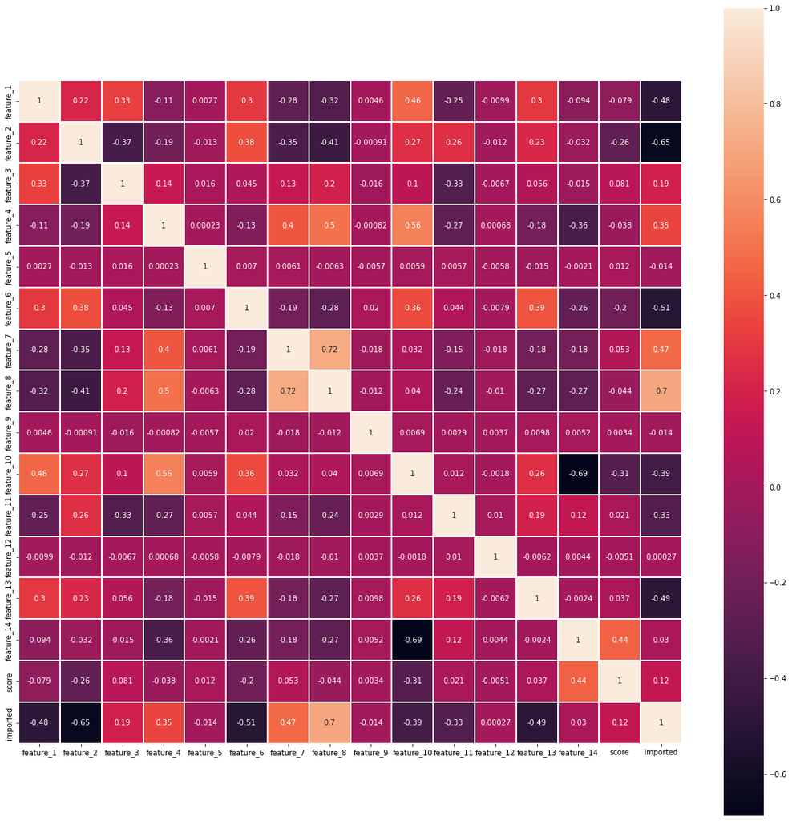

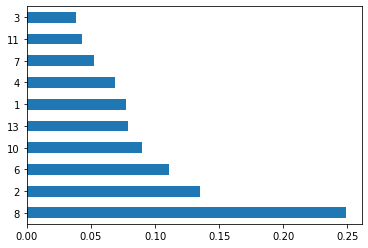

```python
plt.figure(figsize=(20,20))
sns.heatmap(df_beverages.astype(float).corr(),linewidths=0.1,vmax=1.0,
            square=True,  linecolor='white', annot=True)
plt.show()



#feature importance graph
model = ExtraTreesClassifier()
x = df_beverages.iloc[:,:-1].values
y = df_beverages[df_beverages.columns[-1]]
indexss=[1,2,3,4,5,6,7,8,9,10,11,12,13,14,15]
model.fit(x,y)
feat_importances = pd.Series(model.feature_importances_,index=indexss)
feat_importances.nlargest(10).plot(kind='barh')
plt.show()

#corrs = df_beverages.astype(float).corr()
#corrs[:,-1]
```

#### Select top 11 featurs for your classification [2]

```python
# features that will be removed will be feature 5, feature 9 , feature 12 and feature 14 because there corrolations are of the
#lowes as well as their position on the feature importance graph

df_beverages=df_beverages.drop(columns=['feature_9', 'feature_5','feature_12','feature_14'])
print(df_beverages)
```

```
      feature_1  feature_2  feature_3  feature_4  feature_6  feature_7  \
1           7.8       0.88       0.00        2.6      0.098       25.0
2           7.8       0.76       0.04        2.3      0.092       15.0
3          11.2       0.28       0.56        1.9      0.075       17.0
4           7.4       0.70       0.00        1.9      0.076       11.0
5           7.4       0.66       0.00        1.8      0.075       13.0
...         ...        ...        ...        ...        ...        ...
6492        6.2       0.21       0.29        1.6      0.039       24.0
6493        6.6       0.32       0.36        8.0      0.047       57.0
6494        6.5       0.24       0.19        1.2      0.041       30.0
6495        5.5       0.29       0.30        1.1      0.022       20.0
6496        6.0       0.21       0.38        0.8      0.020       22.0

      feature_8  feature_10  feature_11  feature_13  score  imported
1          67.0     0.99680        3.20        0.68      5         0
2          54.0     0.99700        3.26        0.65      5         0
3          60.0     0.99800        3.16        0.58      6         0
4          34.0     0.99780        3.51        0.56      5         0
5          40.0     0.99780        3.51        0.56      5         0
...         ...         ...         ...         ...    ...       ...
6492       92.0     0.99114        3.27        0.50      6         1
6493      168.0     0.99490        3.15        0.46      5         1
6494      111.0     0.99254        2.99        0.46      6         1
6495      110.0     0.98869        3.34        0.38      7         1
6496       98.0     0.98941        3.26        0.32      6         1

[6346 rows x 12 columns]
```

#### Using a virtualization method that you deem appropriate, compare local and imported beverage by their properties [11]

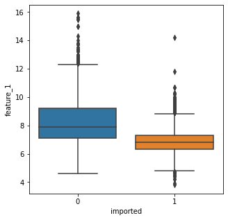

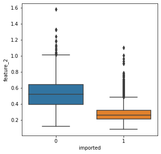

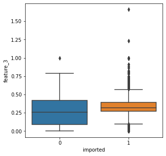

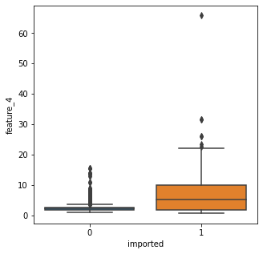

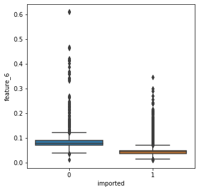

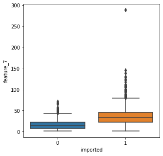

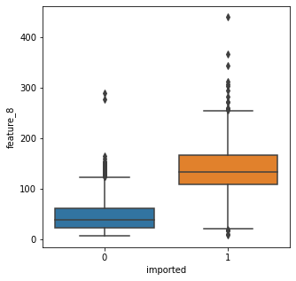

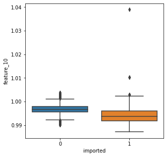

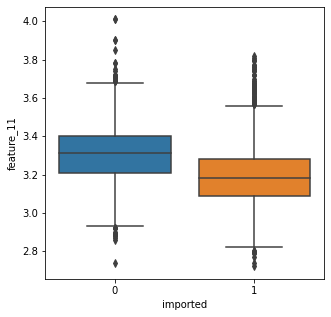

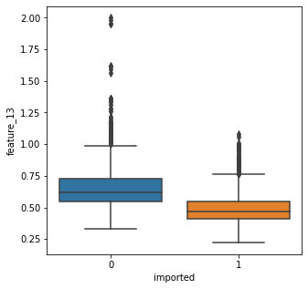

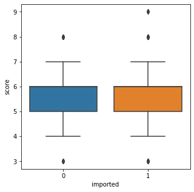

```python
def plotbox(x):
    features=['feature_1','feature_2','feature_3','feature_4','feature_6','feature_7','feature_8','feature_10','feature_11','feature_13','score']
    for i in features:
        plt.figure(figsize=(5,5))
        sns.boxplot(x['imported'], x[i]).set_xlabel("imported", fontsize = 10)


plotbox(df_beverages)
```